# Guided notes and code for terminal investment

Brad Duthie

# Starting summary

Here are some essential notes and R code toward the goal of producing a complete manuscript on terminal investment. This includes the most important bits of the TerminalInvestment.R (minus some of the early plots that showed survival and fecundity curves – these are echoed out). The last major change made to the R file was to make terminal investment in fecundity proportional to age (edited 10 DEC 2015).

## R code summary

First we define all of the survival and fecundity functions. These include 1) constant, 2) increasing, 3) decreasing, 4) hump-shaped, and 5) u-shaped functions of age. Each function has a low and a high. We start with functions in which survival and fecundity do not change with age.

```r
# Low fecundities and survival probabilities:
constantF.Pr.lo <- function(age) rep(2,length(age)); # Fecundity at age
constantP.Pr.lo <- function(age) rep(0.2,length(age)); # Probability of survival age
constantP.Cu.lo <- function(age){ # Cumulative probability of surviving to age.
    all    <- 1:max(age);
    ret    <- rep(0,length(all));
    tot    <- 1; # Probability of being at age zero (must be one, starting point).
    for(i in 1:length(all)){
        ret[i] <- tot * constantP.Pr.lo(i);
        tot    <- ret[i];
    }
    return(ret[age]);
}
# High fecundities and survival probabilities:
constantF.Pr.hi <- function(age) rep(8,length(age)); # Fecundity at age
constantP.Pr.hi <- function(age) rep(0.8,length(age)); # Probability of survival age
constantP.Cu.hi <- function(age){ # Cumulative probability of surviving to age.
    all    <- 1:max(age);
    ret    <- rep(0,length(all));
    tot    <- 1; # Probability of being at age zero (must be one, starting point).
    for(i in 1:length(all)){
        ret[i] <- tot * constantP.Pr.hi(i);
        tot    <- ret[i];
    }
    return(ret[age]);
}
```

Next, we have the functions in which survival and fecundity increase with increasing age. To avoid creating a divergent series, increases are not linear, but asymptote to some value as $m \to \infty$. Survival probability plateaus at ca 0.692 and 0.99 for low and high probability, respectively.

```r
# Low fecundities and survival probabilities:
exponeupF.Pr.lo <- function(age){
    ret <- rep(0,length(age));
    tot <- 0;
    for(i in 1:length(age)){
        ret[i] <- 1 * sum(1/((5/4)^((1:i)-1))) - 1;
    }
    return(ret);
}
exponeupP.Pr.lo <- function(age) {
    ret <- rep(0,length(age));
    tot <- 0;
    for(i in 1:length(age)){
        ret[i] <- (198/1000) * sum(1/((4/3)^((1:age[i])-1))) - 0.1;
    }
    return(ret);
}
exponeupP.Cu.lo <- function(age){
    all <- 1:max(age);
    ret <- rep(0,length(all));
    tot <- 1;
    for(i in 1:length(all)){
        ret[i] <- tot * exponeupP.Pr.lo(i);
        tot    <- ret[i];
    }
    return(ret[age]);
}
# High fecundities and survival probabilities:
exponeupF.Pr.hi <- function(age){
    ret <- rep(0,length(age));
    tot <- 0;
    for(i in 1:length(age)){
        ret[i] <- 2 * sum(1/((10/9)^((1:i)-1)))
    }
    return(ret);
}

exponeupP.Pr.hi <- function(age) {
    ret <- rep(0,length(age));
    tot <- 0;
    for(i in 1:length(age)){
        ret[i] <- (198/1000) * sum(1/((5/4)^((1:age[i])-1)))
    }
    return(ret);
}

exponeupP.Cu.hi <- function(age){
    all <- 1:max(age);
    ret <- rep(0,length(all));
    tot <- 1;
    for(i in 1:length(all)){
        ret[i] <- tot * exponeupP.Pr.hi(i);
        tot    <- ret[i];
    }
    return(ret[age]);
}
```

```r
# Low fecundities and survival probabilities:
exponednF.Pr.lo <- function(age){
    ret <- rep(0,length(age));
    for(i in 1:length(age)){
        ret[i] <- (15) * exp(-(10/40)*age[i]);
    }
    return(ret);
}
exponednP.Pr.lo <- function(age){
    ret <- rep(0,length(age));
    for(i in 1:length(age)){
        ret[i] <- (0.5) * exp(-(10/40)*age[i]);
    }
    return(ret);
}
exponednP.Cu.lo <- function(age){
    all <- 1:max(age);
    ret <- rep(0,length(all));
    tot <- 1;
    for(i in 1:length(all)){
        ret[i] <- tot * exponednP.Pr.lo(i);
        tot    <- ret[i];
    }
    return(ret[age]);
}
# High fecundities and survival probabilities:
exponednF.Pr.hi <- function(age){
    ret <- rep(0,length(age));
    for(i in 1:length(age)){
        ret[i] <- (30) * exp(-(5/40)*age[i]);
    }
    return(ret);
}
exponednP.Pr.hi <- function(age){
    ret <- rep(0,length(age));
    for(i in 1:length(age)){
        ret[i] <- (1) * exp(-(5/40)*age[i]);
    }
    return(ret);
}
exponednP.Cu.hi <- function(age){
    all <- 1:max(age);
    ret <- rep(0,length(all));
    tot <- 1;
    for(i in 1:length(all)){
        ret[i] <- tot * exponednP.Pr.hi(i);
        tot    <- ret[i];
    }
    return(ret[age]);
}
```

Next, we have hump-shaped survival probabilities and fecundities, in which some maximum value occurs in the middle of life, with lower values for low and high ages.

```r
# Low fecundities and survival probabilities:
humpedshF.Pr.lo <- function(age,sd=5) 10 * (1/sd*sqrt(2*pi))*exp(-1*((age - 10)^2/(2*sd*sd)));
humpedshP.Pr.lo <- function(age,sd=5) (1/sd*sqrt(2*pi))*exp(-1*((age - 10)^2/(2*sd*sd)));
humpedshP.Cu.lo <- function(age,sd=5){
    all <- 1:max(age);
    ret <- rep(0,length(all));
    tot <- 1;
    for(i in 1:length(all)){
        ret[i] <- tot * humpedshP.Pr.lo(i,sd);
        tot    <- ret[i];
    }
    return(ret[age]);
}
# High fecundities and survival probabilities:
humpedshF.Pr.hi <- function(age,sd=5) 20 * (1/sd*sqrt(2*pi))*exp(-1*((age - 10)^2/(2*sd*sd)));
humpedshP.Pr.hi <- function(age,sd=5) 2 * (1/sd*sqrt(2*pi))*exp(-1*((age - 10)^2/(2*sd*sd)));
humpedshP.Cu.hi <- function(age,sd=5){
    all <- 1:max(age);
    ret <- rep(0,length(all));
    tot <- 1;
    for(i in 1:length(all)){
        ret[i] <- tot * humpedshP.Pr.hi(i,sd);
        tot    <- ret[i];
    }
    return(ret[age]);
}
```

Lastly, we consider u-shaped survival probabilities and fecundities, in which a minimum value occurs in the middle of life, with higher values for low and high ages.

```r
# Low fecundities and survival probabilities:
UshF.Pr.lo <- function(age,sd=5) 10 - 18*(1/sd*sqrt(2*pi))*exp(-1*((age - 10)^2/(2*sd*sd)));
UshP.Pr.lo <- function(age,sd=5) 0.6 - (1/sd*sqrt(2*pi))*exp(-1*((age - 10)^2/(2*sd*sd)));
UshP.Cu.lo <- function(age,sd=5){
    all <- 1:max(age);
    ret <- rep(0,length(all));
    tot <- 1;
    for(i in 1:length(all)){
        ret[i] <- tot * UshP.Pr.lo(i,sd);
        tot    <- ret[i];
    }
    return(ret[age]);
}
# High fecundities and survival probabilities:
UshF.Pr.hi <- function(age,sd=5) 15 - 18*(1/sd*sqrt(2*pi))*exp(-1*((age - 10)^2/(2*sd*sd)));
UshP.Pr.hi <- function(age,sd=5) 1 - (1/sd*sqrt(2*pi))*exp(-1*((age - 10)^2/(2*sd*sd)));
UshP.Cu.hi <- function(age,sd=5){
    all <- 1:max(age);
    ret <- rep(0,length(all));
    tot <- 1;
    for(i in 1:length(all)){
        ret[i] <- tot * UshP.Pr.hi(i,sd);
        tot    <- ret[i];
    }
    return(ret[age]);
}
```

Using the above survival and fecundity curves, we can predict terminal investment using the equation derived from our modelling work,

$$\Delta m_x + \frac{ \Delta RV_{0} \left(m_x + \Delta m_{x}\right)}{ 2 + RV_0 } > RV'_{x}$$

In the above, $m_{x}$ is fecundity at age $x$, while $\Delta m_{x}$ is the gain in fecundity from terminally investing in age $x$. Similarly, $RV_{0}$ is the reproductive value of offspring, and $\Delta RV_{0}$ is the increase in the reproductive value of offspring after termainal investment. The term $RV'_{x}$ is the residual reproductive value of an individual that does not terminally invest. Hence, terminal investment increases fitness if the left-hand side of the above equation is greater than the residual reproductive value of a female. To analyse our model, we define the equivalent function in R below.

```r
lhs <- function(Dmx, DRV0, mx, RV0, RVx){
    ti <- Dmx + (DRV0 * (mx + Dmx)) / (2 + RV0);
    if(ti > RVx){
        return(1);
    }else{
        return(0);
    }
}
```

```r
TIspace <- function(FecFun,SurFun,yr=20,yF=1,yR=1){
    resvals <- rep(x=0, times=yr+1);
    termi   <- 1000;
    for(i in 1:(yr+1)){
        resvals[i] <- sum((SurFun(i:termi)/SurFun(i))*FecFun(i:termi));
    }
    Fpar  <- seq(from=0, to=yF, length.out=100);
    Rpar  <- seq(from=0, to=yR, length.out=100);
    Space <- array(data=0,dim=c(100,100,yr));
    for(age in 1:dim(Space)[3]){
        for(i in 1:dim(Space)[1]){
            for(j in 1:dim(Space)[2]){
                CHECK <- lhs( Dmx  =  Fpar[i] * FecFun(i),   # TI in fecundity
                              DRV0 =  Rpar[j],                   # TI in RV of offspring
                              mx   =  FecFun(age),               # Age fecundity
                              RV0  =  resvals[1],                # Offspring RV
                              RVx  =  resvals[age+1]             # RV at age x
                        );
                Space[i,j,age] <- CHECK;
            }
        }
    }
    return(Space);
}
```

Below we can create a list of all the fecundity functions `Ffun` and all the survival functions `Sfun`.

```r
Ffun  <- list(constantF.Pr.lo, constantF.Pr.hi, exponeupF.Pr.lo, exponeupF.Pr.hi,
              exponednF.Pr.lo, exponednF.Pr.hi, humpedshF.Pr.lo, humpedshF.Pr.hi,
              UshF.Pr.lo, UshF.Pr.hi);
Sfun  <- list(constantP.Cu.lo, constantP.Cu.hi, exponeupP.Cu.lo, exponeupP.Cu.hi,
              exponednP.Cu.lo, exponednP.Cu.hi, humpedshP.Cu.lo, humpedshP.Cu.hi,
              UshP.Cu.lo, UshP.Cu.hi);
Ffunl <-    c("constantF.Pr.lo", "constantF.Pr.hi", "exponeupF.Pr.lo", "exponeupF.Pr.hi",
              "exponednF.Pr.lo", "exponednF.Pr.hi", "humpedshF.Pr.lo", "humpedshF.Pr.hi",
              "UshF.Pr.lo", "UshF.Pr.hi");
Sfunl <-    c("constantP.Cu.lo", "constantP.Cu.hi", "exponeupP.Cu.lo", "exponeupP.Cu.hi",
              "exponednP.Cu.lo", "exponednP.Cu.hi", "humpedshP.Cu.lo", "humpedshP.Cu.hi",
              "UshP.Cu.lo", "UshP.Cu.hi");
```

We can then loop through these lists to find where terminal investment is predicted.

```r
rmat <- NULL;
for(i in 1:length(Ffun)){
  for(j in 1:length(Sfun)){
    chk  <- TIspace(FecFun=Ffun[[i]], SurFun=Sfun[[j]]);
    tot  <- sum(chk) / length(chk);
    res  <- c(Ffunl[i], Sfunl[j], tot);
    rmat <- rbind(rmat,res);
  }
}
colnames(rmat) <- c("Fecundity", "Survival", "TI sum");
#print(rmat);
ord  <- order(x=as.numeric(rmat[,3]),decreasing=TRUE);
print(rmat[ord,]);
```

```
##     Fecundity         Survival          TI sum
## res "UshF.Pr.lo"      "exponednP.Cu.lo" "0.532035"
## res "UshF.Pr.lo"      "constantP.Cu.lo" "0.45451"
## res "UshF.Pr.lo"      "humpedshP.Cu.lo" "0.43997"
## res "UshF.Pr.lo"      "exponednP.Cu.hi" "0.429305"
## res "UshF.Pr.lo"      "UshP.Cu.lo"      "0.38048"
## res "UshF.Pr.hi"      "exponednP.Cu.lo" "0.353695"
## res "UshF.Pr.hi"      "constantP.Cu.lo" "0.248515"
## res "UshF.Pr.hi"      "exponednP.Cu.hi" "0.214635"
## res "UshF.Pr.hi"      "UshP.Cu.lo"      "0.211945"
## res "UshF.Pr.hi"      "humpedshP.Cu.lo" "0.15312"
## res "constantF.Pr.lo" "exponednP.Cu.lo" "0.144115"
## res "UshF.Pr.lo"      "exponeupP.Cu.lo" "0.134955"
## res "exponeupF.Pr.hi" "exponednP.Cu.lo" "0.10028"
## res "UshF.Pr.lo"      "humpedshP.Cu.hi" "0.06818"
## res "constantF.Pr.hi" "exponednP.Cu.lo" "0.04538"
## res "constantF.Pr.lo" "humpedshP.Cu.lo" "0.041505"
## res "constantF.Pr.lo" "constantP.Cu.lo" "0.038"
## res "exponeupF.Pr.hi" "humpedshP.Cu.lo" "0.020405"
## res "constantF.Pr.lo" "UshP.Cu.lo"      "0.01937"
## res "constantF.Pr.lo" "exponednP.Cu.hi" "0.016185"
## res "constantF.Pr.lo" "humpedshP.Cu.hi" "0.015795"
## res "exponednF.Pr.lo" "exponednP.Cu.lo" "0.015285"
## res "exponednF.Pr.lo" "humpedshP.Cu.lo" "0.01407"
## res "exponednF.Pr.lo" "exponednP.Cu.hi" "0.012975"
## res "exponednF.Pr.lo" "humpedshP.Cu.hi" "0.012495"
## res "exponednF.Pr.lo" "constantP.Cu.lo" "0.011235"
## res "constantF.Pr.hi" "humpedshP.Cu.lo" "0.00793"
## res "humpedshF.Pr.lo" "humpedshP.Cu.lo" "0.00655"
## res "UshF.Pr.hi"      "humpedshP.Cu.hi" "0.006515"
## res "humpedshF.Pr.lo" "exponednP.Cu.lo" "0.006435"
## res "humpedshF.Pr.hi" "humpedshP.Cu.lo" "0.00503"
## res "humpedshF.Pr.hi" "exponednP.Cu.lo" "0.004865"
## res "humpedshF.Pr.lo" "humpedshP.Cu.hi" "0.00474"
## res "humpedshF.Pr.lo" "constantP.Cu.lo" "0.004685"
## res "exponednF.Pr.lo" "UshP.Cu.lo"      "0.003435"
## res "humpedshF.Pr.lo" "exponednP.Cu.hi" "0.003435"
## res "humpedshF.Pr.hi" "humpedshP.Cu.hi" "0.003435"
## res "humpedshF.Pr.hi" "constantP.Cu.lo" "0.00334"
## res "humpedshF.Pr.hi" "exponednP.Cu.hi" "0.0029"
```

[output cut: 46 more lines]

```
## res "exponednF.Pr.hi" "UshP.Cu.hi"      "0"
## res "humpedshF.Pr.lo" "constantP.Cu.hi" "0"
## res "humpedshF.Pr.lo" "exponeupP.Cu.hi" "0"
## res "humpedshF.Pr.lo" "UshP.Cu.hi"      "0"
## res "humpedshF.Pr.hi" "constantP.Cu.hi" "0"
## res "humpedshF.Pr.hi" "exponeupP.Cu.lo" "0"
## res "humpedshF.Pr.hi" "exponeupP.Cu.hi" "0"
## res "humpedshF.Pr.hi" "UshP.Cu.hi"      "0"
## res "UshF.Pr.lo"      "constantP.Cu.hi" "0"
## res "UshF.Pr.lo"      "exponeupP.Cu.hi" "0"
## res "UshF.Pr.lo"      "UshP.Cu.hi"      "0"
## res "UshF.Pr.hi"      "constantP.Cu.hi" "0"
## res "UshF.Pr.hi"      "exponeupP.Cu.lo" "0"
## res "UshF.Pr.hi"      "exponeupP.Cu.hi" "0"
## res "UshF.Pr.hi"      "UshP.Cu.hi"      "0"
```

# Building some key figures

We can build a figure showing all of the fecundity and survival curves below.

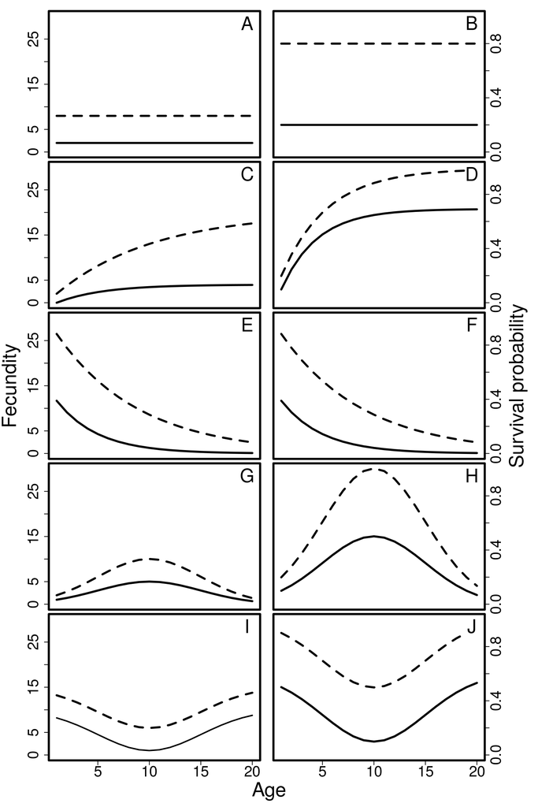

```r
x <- 1:20;
# ---------------------------------------------------
y <- constantF.Pr.lo(x);
par(mfrow=c(5,2),mar=c(0.25,0.5,0.25,1),lwd=3,oma=c(5,5,1,5));
plot(x=x,y=y,type="l",xlab="",ylab="",lwd=3,ylim=c(0,30),cex.lab=2,yaxt="n",xaxt="n");
axis(side=2,at=c(0,5,10,15,20,25),cex.axis=2);
y <- constantF.Pr.hi(x);
points(x=x,y=y,type="l",lwd=3,lty="dashed");
y <- constantP.Pr.lo(x);
text(x=19.5,y=28.5,labels="A",cex=2.5);
plot(x=x,y=y,type="l",xlab="",ylab="",lwd=3,ylim=c(0,1),cex.lab=2,yaxt="n",xaxt="n");
axis(side=4,at=c(0,0.2,0.4,0.6,0.8),cex.axis=2);
y <- constantP.Pr.hi(x);
points(x=x,y=y,type="l",lwd=3,lty="dashed");
text(x=19.5,y=28.5/30,labels="B",cex=2.5);
# ---------------------------------------------------
y <- exponeupF.Pr.lo(x);
plot(x=x,y=y,type="l",xlab="",ylab="",lwd=3,ylim=c(0,30),cex.lab=2,yaxt="n",xaxt="n");
axis(side=2,at=c(0,5,10,15,20,25),cex.axis=2);
y <- exponeupF.Pr.hi(x);
points(x=x,y=y,type="l",lwd=3,lty="dashed");
y <- exponeupP.Pr.lo(x);
text(x=19.5,y=28.5,labels="C",cex=2.5);
plot(x=x,y=y,type="l",xlab="",ylab="",lwd=3,ylim=c(0,1),cex.lab=2,yaxt="n",xaxt="n");
axis(side=4,at=c(0,0.2,0.4,0.6,0.8),cex.axis=2);
y <- exponeupP.Pr.hi(1:19);
points(x=1:19,y=y,type="l",lwd=3,lty="dashed");
text(x=19.5,y=28.5/30,labels="D",cex=2.5);
# ---------------------------------------------------
y <- exponednF.Pr.lo(x);
plot(x=x,y=y,type="l",xlab="",ylab="",lwd=3,ylim=c(0,30),cex.lab=2,yaxt="n",xaxt="n");
axis(side=2,at=c(0,5,10,15,20,25),cex.axis=2);
y <- exponednF.Pr.hi(x);
points(x=x,y=y,type="l",lwd=3,lty="dashed");
y <- exponednP.Pr.lo(x);
text(x=19.5,y=28.5,labels="E",cex=2.5);
plot(x=x,y=y,type="l",xlab="",ylab="",lwd=3,ylim=c(0,1),cex.lab=2,yaxt="n",xaxt="n");
axis(side=4,at=c(0,0.2,0.4,0.6,0.8),cex.axis=2);
y <- exponednP.Pr.hi(x);
points(x=x,y=y,type="l",lwd=3,lty="dashed");
text(x=19.5,y=28.5/30,labels="F",cex=2.5);
# ---------------------------------------------------
y <- humpedshF.Pr.lo(x);
plot(x=x,y=y,type="l",xlab="",ylab="",lwd=3,ylim=c(0,30),cex.lab=2,yaxt="n",xaxt="n");
axis(side=2,at=c(0,5,10,15,20,25),cex.axis=2);
y <- humpedshF.Pr.hi(x);
points(x=x,y=y,type="l",lwd=3,lty="dashed");
y <- humpedshP.Pr.lo(x);
text(x=19.5,y=28.5,labels="G",cex=2.5);
plot(x=x,y=y,type="l",xlab="",ylab="",lwd=3,ylim=c(0,1),cex.lab=2,yaxt="n",xaxt="n");
axis(side=4,at=c(0,0.2,0.4,0.6,0.8),cex.axis=2);
y <- humpedshP.Pr.hi(x);
points(x=x,y=y,type="l",lwd=3,lty="dashed");
text(x=19.5,y=28.5/30,labels="H",cex=2.5);
# ---------------------------------------------------
y <- UshF.Pr.lo(x);
plot(x=x,y=y,type="l",xlab="",ylab="",lwd=2,ylim=c(0,30),cex.lab=2,yaxt="n",xaxt="n");
axis(side=2,at=c(0,5,10,15,20,25),cex.axis=2);
axis(side=1,at=c(0,5,10,15,20),cex.axis=2);
y <- UshF.Pr.hi(x);
points(x=x,y=y,type="l",lwd=3,lty="dashed");
y <- UshP.Pr.lo(x);
text(x=19.5,y=28.5,labels="I",cex=2.5);
plot(x=x,y=y,type="l",xlab="",ylab="",lwd=3,ylim=c(0,1),cex.lab=2,yaxt="n",xaxt="n");
axis(side=4,at=c(0,0.2,0.4,0.6,0.8),cex.axis=2);
y <- UshP.Pr.hi(1:19);
points(x=1:19,y=y,type="l",lwd=3,lty="dashed");
text(x=19.5,y=28.5/30,labels="J",cex=2.5);
axis(side=1,at=c(0,5,10,15,20),cex.axis=2);

mtext(expression(paste("Age")),
    outer=TRUE,side=1,line=3.5,cex=1.75);

mtext(expression(paste("Fecundity")),
    outer=TRUE,side=2,line=2.5,cex=1.75);

mtext(expression(paste("Survival probability")),
    outer=TRUE,side=4,line=3,cex=1.75);
```

# Consider only up to 99.9% mortality (25 NOV 2016)

```r
# Just put in a survival distribution, max possible years is 1000
age_cutoff <- function(survival.distr, max=1000){
    cumulatives <- survival.distr(1:max) * max; # Criteria now > 1
    cutoff      <- sum(cumulatives >= 1);
    return(cutoff);
}
```

Now we can set the age explicitly when looping through all combinations of survival and fecundity functions. This makes a table that is comparable to the table listed above in which the maximum age was always 20.

```r
rmat <- NULL;
for(i in 1:length(Ffun)){
  for(j in 1:length(Sfun)){
    cut  <- age_cutoff(Sfun[[j]]);
    chk  <- TIspace(FecFun=Ffun[[i]], SurFun=Sfun[[j]], yr=cut);
    tot  <- sum(chk) / length(chk);
    res  <- c(Ffunl[i], Sfunl[j], tot);
    rmat <- rbind(rmat,res);
  }
}
colnames(rmat) <- c("Fecundity", "Survival", "TI sum");
#print(rmat);
ord  <- order(x=as.numeric(rmat[,3]),decreasing=TRUE);
print(rmat[ord,]);
```

```
##     Fecundity         Survival          TI sum
## res "humpedshF.Pr.lo" "exponeupP.Cu.hi" "0.595146666666667"
## res "humpedshF.Pr.hi" "exponeupP.Cu.hi" "0.575441666666667"
## res "exponednF.Pr.lo" "exponeupP.Cu.hi" "0.502209166666667"
## res "UshF.Pr.lo"      "exponednP.Cu.hi" "0.49132"
## res "UshF.Pr.lo"      "UshP.Cu.lo"      "0.387383333333333"
## res "exponednF.Pr.hi" "exponeupP.Cu.hi" "0.382028333333333"
## res "UshF.Pr.lo"      "exponednP.Cu.lo" "0.3441"
## res "UshF.Pr.lo"      "constantP.Cu.lo" "0.33195"
## res "UshF.Pr.lo"      "humpedshP.Cu.lo" "0.231933333333333"
## res "UshF.Pr.hi"      "exponednP.Cu.hi" "0.22414"
## res "UshF.Pr.lo"      "exponeupP.Cu.lo" "0.194516666666667"
## res "UshF.Pr.hi"      "UshP.Cu.lo"      "0.193033333333333"
## res "UshF.Pr.hi"      "exponednP.Cu.lo" "0.175275"
## res "UshF.Pr.hi"      "constantP.Cu.lo" "0.14815"
## res "humpedshF.Pr.lo" "constantP.Cu.hi" "0.0618233333333333"
## res "humpedshF.Pr.hi" "constantP.Cu.hi" "0.0610233333333333"
## res "constantF.Pr.lo" "exponednP.Cu.lo" "0.0572"
## res "UshF.Pr.lo"      "humpedshP.Cu.hi" "0.0536933333333333"
## res "exponednF.Pr.lo" "constantP.Cu.hi" "0.0419366666666667"
## res "UshF.Pr.hi"      "humpedshP.Cu.lo" "0.0409"
## res "constantF.Pr.lo" "constantP.Cu.lo" "0.038"
## res "constantF.Pr.lo" "humpedshP.Cu.lo" "0.0162666666666667"
## res "constantF.Pr.lo" "UshP.Cu.lo"      "0.0159333333333333"
## res "exponeupF.Pr.hi" "exponednP.Cu.lo" "0.004875"
## res "constantF.Pr.hi" "exponednP.Cu.lo" "0.000975"
## res "constantF.Pr.lo" "constantP.Cu.hi" "0"
## res "constantF.Pr.lo" "exponeupP.Cu.lo" "0"
## res "constantF.Pr.lo" "exponeupP.Cu.hi" "0"
## res "constantF.Pr.lo" "exponednP.Cu.hi" "0"
## res "constantF.Pr.lo" "humpedshP.Cu.hi" "0"
## res "constantF.Pr.lo" "UshP.Cu.hi"      "0"
## res "constantF.Pr.hi" "constantP.Cu.lo" "0"
## res "constantF.Pr.hi" "constantP.Cu.hi" "0"
## res "constantF.Pr.hi" "exponeupP.Cu.lo" "0"
## res "constantF.Pr.hi" "exponeupP.Cu.hi" "0"
## res "constantF.Pr.hi" "exponednP.Cu.hi" "0"
## res "constantF.Pr.hi" "humpedshP.Cu.lo" "0"
## res "constantF.Pr.hi" "humpedshP.Cu.hi" "0"
## res "constantF.Pr.hi" "UshP.Cu.lo"      "0"
```

[output cut: 46 more lines]

```
## res "humpedshF.Pr.hi" "exponeupP.Cu.lo" "0"
## res "humpedshF.Pr.hi" "exponednP.Cu.lo" "0"
## res "humpedshF.Pr.hi" "exponednP.Cu.hi" "0"
## res "humpedshF.Pr.hi" "humpedshP.Cu.lo" "0"
## res "humpedshF.Pr.hi" "humpedshP.Cu.hi" "0"
## res "humpedshF.Pr.hi" "UshP.Cu.lo"      "0"
## res "humpedshF.Pr.hi" "UshP.Cu.hi"      "0"
## res "UshF.Pr.lo"      "constantP.Cu.hi" "0"
## res "UshF.Pr.lo"      "exponeupP.Cu.hi" "0"
## res "UshF.Pr.lo"      "UshP.Cu.hi"      "0"
## res "UshF.Pr.hi"      "constantP.Cu.hi" "0"
## res "UshF.Pr.hi"      "exponeupP.Cu.lo" "0"
## res "UshF.Pr.hi"      "exponeupP.Cu.hi" "0"
## res "UshF.Pr.hi"      "humpedshP.Cu.hi" "0"
## res "UshF.Pr.hi"      "UshP.Cu.hi"      "0"
```

Similarly, we can build a figure showing what each curve *really* looks like, given our cutoff threshold for mortality.

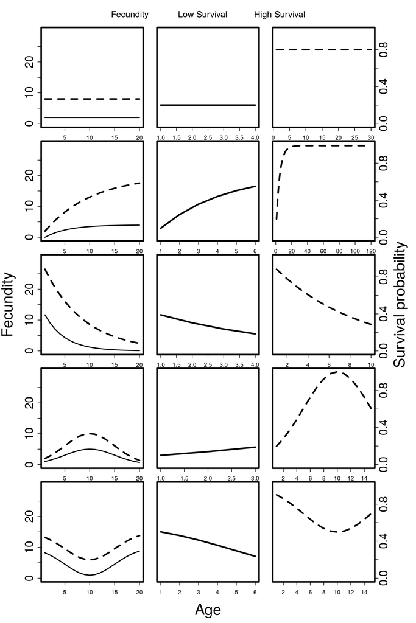

```r
x <- 1:20;
# ---------------------------------------------------
y <- constantF.Pr.lo(x);
par(mfrow=c(5,3),mar=c(1,1,1,1),lwd=3,oma=c(5,5,3,5));
plot(x=x,y=y,type="l",xlab="",ylab="",lwd=2,ylim=c(0,30),cex.lab=1,yaxt="n");
axis(side=2,at=c(0,5,10,15,20,25),cex.axis=2);
y <- constantF.Pr.hi(x);
points(x=x,y=y,type="l",lwd=3,lty="dashed");

a <- age_cutoff(constantP.Cu.lo);
y <- constantP.Pr.lo(1:a);
#text(x=19.5,y=28.5,labels="A",cex=2.5);
plot(x=1:a,y=y,type="l",xlab="",ylab="",lwd=3,ylim=c(0,1),cex.lab=2,yaxt="n");
a <- age_cutoff(constantP.Cu.hi);
y <- constantP.Pr.hi(1:a);
plot(x=1:a,y=y,type="l",xlab="",ylab="",lwd=3,ylim=c(0,1),cex.lab=2,lty="dashed",yaxt="n");
axis(side=4,at=c(0,0.2,0.4,0.6,0.8),cex.axis=2);
#text(x=1,y=28.5/30,labels="B",cex=2.5);
# ---------------------------------------------------
y <- exponeupF.Pr.lo(x);
plot(x=x,y=y,type="l",xlab="",ylab="",lwd=2,ylim=c(0,30),cex.lab=1,yaxt="n");
axis(side=2,at=c(0,5,10,15,20,25),cex.axis=2);
y <- exponeupF.Pr.hi(x);
points(x=x,y=y,type="l",lwd=3,lty="dashed");

a <- age_cutoff(exponeupP.Cu.lo);
y <- exponeupP.Pr.lo(1:a);
#text(x=19.5,y=28.5,labels="C",cex=2.5);
plot(x=1:a,y=y,type="l",xlab="",ylab="",lwd=3,ylim=c(0,1),cex.lab=2,yaxt="n");
a <- age_cutoff(exponeupP.Cu.hi);
y <- exponeupP.Pr.hi(1:a);
plot(x=1:a,y=y,type="l",xlab="",ylab="",lwd=3,ylim=c(0,1),cex.lab=2,yaxt="n",lty="dashed");
axis(side=4,at=c(0,0.2,0.4,0.6,0.8),cex.axis=2);
#text(x=1,y=28.5/30,labels="D",cex=2.5);
# ---------------------------------------------------
y <- exponednF.Pr.lo(x);
plot(x=x,y=y,type="l",xlab="",ylab="",lwd=2,ylim=c(0,30),cex.lab=1,yaxt="n");
axis(side=2,at=c(0,5,10,15,20,25),cex.axis=2);
y <- exponednF.Pr.hi(x);
points(x=x,y=y,type="l",lwd=3,lty="dashed");

a <- age_cutoff(exponednP.Cu.lo);
y <- exponednP.Pr.lo(1:a);
#text(x=19.5,y=28.5,labels="E",cex=2.5);
plot(x=1:a,y=y,type="l",xlab="",ylab="",lwd=3,ylim=c(0,1),cex.lab=2,yaxt="n");
a <- age_cutoff(exponednP.Cu.hi);
y <- exponednP.Pr.hi(1:a);
plot(x=1:a,y=y,type="l",xlab="",ylab="",lwd=3,ylim=c(0,1),cex.lab=2,yaxt="n",lty="dashed");
axis(side=4,at=c(0,0.2,0.4,0.6,0.8),cex.axis=2);
#text(x=1,y=28.5/30,labels="F",cex=2.5);
# ---------------------------------------------------
y <- humpedshF.Pr.lo(x);
plot(x=x,y=y,type="l",xlab="",ylab="",lwd=2,ylim=c(0,30),cex.lab=1,yaxt="n");
axis(side=2,at=c(0,5,10,15,20,25),cex.axis=2);
y <- humpedshF.Pr.hi(x);
points(x=x,y=y,type="l",lwd=3,lty="dashed");

a <- age_cutoff(humpedshP.Cu.lo);
y <- humpedshP.Pr.lo(1:a);
#text(x=19.5,y=28.5,labels="G",cex=2.5);
plot(x=1:a,y=y,type="l",xlab="",ylab="",lwd=3,ylim=c(0,1),cex.lab=2,yaxt="n");
a <- age_cutoff(humpedshP.Cu.hi);
y <- humpedshP.Pr.hi(1:a);
plot(x=1:a,y=y,type="l",xlab="",ylab="",lwd=3,ylim=c(0,1),cex.lab=2,yaxt="n",lty="dashed");
axis(side=4,at=c(0,0.2,0.4,0.6,0.8),cex.axis=2);
#text(x=1,y=28.5/30,labels="H",cex=2.5);
# ---------------------------------------------------
y <- UshF.Pr.lo(x);
plot(x=x,y=y,type="l",xlab="",ylab="",lwd=2,ylim=c(0,30),cex.lab=1,yaxt="n");
axis(side=2,at=c(0,5,10,15,20,25),cex.axis=2);
#axis(side=1,at=c(0,5,10,15,20),cex.axis=2);
y <- UshF.Pr.hi(x);
points(x=x,y=y,type="l",lwd=3,lty="dashed");

a <- age_cutoff(UshP.Cu.lo);
y <- UshP.Pr.lo(1:a);
#text(x=19.5,y=28.5,labels="I",cex=2.5);
plot(x=1:a,y=y,type="l",xlab="",ylab="",lwd=3,ylim=c(0,1),cex.lab=2,yaxt="n");

a <- age_cutoff(UshP.Cu.hi);
y <- UshP.Pr.hi(1:a);
plot(x=1:a,y=y,type="l",xlab="",ylab="",lwd=3,ylim=c(0,1),cex.lab=2,yaxt="n",lty="dashed");
axis(side=4,at=c(0,0.2,0.4,0.6,0.8),cex.axis=2);
#text(x=1,y=28.5/30,labels="J",cex=2.5);


mtext(expression(paste("Fecundity            Low Survival           High Survival")),
    outer=TRUE,side=3,cex=1);

mtext(expression(paste("Age")),
    outer=TRUE,side=1,line=3.5,cex=1.75);

mtext(expression(paste("Fecundity")),
    outer=TRUE,side=2,line=2.5,cex=1.75);

mtext(expression(paste("Survival probability")),
    outer=TRUE,side=4,line=3,cex=1.75);
```

The differences on the x-axis of survival (middle and right columns) show that there is quite a bit of variance among different types of curves. Further, for the low survival, the hump-shaped and u-shaped curves aren’t actually humped or -ushaped because survival to the relevant age is almost zero. It is tempting to only look at high survival probability, in light of this.